# **Exploring How Daily Habits Impact Productivity in Students**

Fall 2026 Data Science Project  
Group Members: Avery Budlong, Anantrao Chinta, Aarya Vijayaraghavan, Christopher Ocloo, Liya Solomon, Marvi Shukla

**Contributions**

| Name | Sections | Description |
| --- | --- | --- |
| Avery Budlong | C, G | Analysis and visualization for EDA. Hosted final report in GitHub |
| Anantrao Chinta | A, E, F | Proposed project idea. Worked on machine learning analysis for linear/polynomial regression, developed visualizations, analyzed performance. |
| Aarya Vijayaraghavan | C, E | Worked on development, plots, and analysis for EDA. Worked on ML algorithm analysis |
| Christopher Ocloo | C | Used statistical analysis, hypothesis testing, and data visualizations to identify key patterns, relationships, and characteristics within the dataset. |
| Liya Solomon | B, G | Completed the primary data curation and preprocessing by parsing multiple datasets into numeric formats and cleaning the data. Also wrote the introduction. |
| Marvi Shukla | E, F | Neural Network, comparative data visualization between the neural network and linear regression models, insights and conclusions |

# Introduction

The intersection of technology and academic life represents a significant area of study for modern university students. As digital devices become insperable from the learning process, understanding how daily habits like screen time and sleep affect productivity is essential for optimizing academic performance, productivity, and mental health. This project explores the relationships between digital consumption, physical rest, and cognitive output to identify patterns that contribute to or hinder student success. The primary objective is to determine how various behaviors correlate with measurable outcomes like productivity. We hope to use machine learning models to be able to quantify the affect of these habits on student success and also predict productivity based on daily habits. By addressing the influence of screen time, sleep duration, the correlation between phone usage and productivity scores, and the ability of machine learning models to predict productivity, this tutorial provides evidence based insights into healthy habits for the modern student.

# Data curation

This analysis will focus on the dataset "Student Productivity & Digital Distraction Dataset." It was published by Mansehaj Preet and obtained from Kaggle here: dataset. The dataset includes data from 20,000 students on sleep, daily habits, studying, phone usage, attendance, productivity, and more.

Additionally, we used the dataset "Impact of Screen Time on Mental Health." It was published by Khushi Yadav and obtained [here](https://www.kaggle.com/datasets/khushikyad001/impact-of-screen-time-on-mental-health). This dataset has data from 2000 individuals about their technology usage and mental health.

To prepare the data for analysis we will load the dataset into a pandas DataFrame and do some cleaning including making all columns numeric for future machine learning training and removing null entries.

```python
import pandas as pd
import numpy as np

df_prod = pd.read_csv('student_productivity_distraction_dataset_20000.csv')
df_diet = pd.read_csv('digital_diet_mental_health.csv')

# Parsing the productivity data
df_prod['phone_usage_hours'] = pd.to_numeric(df_prod['phone_usage_hours'], errors='coerce')
df_prod['study_hours_per_day'] = pd.to_numeric(df_prod['study_hours_per_day'], errors='coerce')
df_prod['productivity_score'] = pd.to_numeric(df_prod['productivity_score'], errors='coerce')
df_prod['sleep_hours'] = pd.to_numeric(df_prod['sleep_hours'], errors='coerce')

# parsing the diet data
df_diet['daily_screen_time_hours'] = pd.to_numeric(df_diet['daily_screen_time_hours'], errors='coerce')

# Cleaning the datasets by removing rows with missing values
df_prod_clean = df_prod.dropna(subset=['phone_usage_hours', 'study_hours_per_day', 'productivity_score', 'sleep_hours'])
df_diet_clean = df_diet.dropna(subset=['daily_screen_time_hours'])


# Summarizing the final datasets
print(f"Productivity Dataset: {df_prod_clean.shape[0]} entries, {df_prod_clean.shape[1]} features")
print(f"Diet: {df_diet_clean.shape[0]} entries, {df_diet_clean.shape[1]} features")

df_prod = df_prod_clean
print("---------------------------------- student_productivity_distraction_dataset ------------------------------------------------")
print(df_prod.head())
print("\n---------------------------------- digital_diet_mental_health ------------------------------------------------")
print(df_diet_clean.head())
```

```
Productivity Dataset: 20000 entries, 18 features
Diet: 2000 entries, 25 features
---------------------------------- student_productivity_distraction_dataset ------------------------------------------------
   student_id  age  gender  study_hours_per_day  sleep_hours  \
0           1   23  Female                 4.35         3.63
1           2   20    Male                 6.14         6.58
2           3   29  Female                 4.98         3.26
3           4   27  Female                 3.19         4.58
4           5   24    Male                 7.67         6.21

   phone_usage_hours  social_media_hours  youtube_hours  gaming_hours  \
0               3.38                2.73           1.83          5.26
1               5.48                1.51           3.13          1.73
2               4.83                3.63           0.18          4.71
3              10.06                3.95           5.75          2.52
4               3.02                1.59           5.46          5.65

   breaks_per_day  coffee_intake_mg  exercise_minutes  assignments_completed  \
0               6               347               111                      2
1              13               403                28                     10
2               1               419               102                      8
3               9               178                28                     18
4               8               436               105                      7

   attendance_percentage  stress_level  focus_score  final_grade  \
0                  57.21            10           57        81.87
1                  91.27            10           49        60.90
2                  63.14             2           38        86.22
3                  40.51             6           50        71.77
4                  45.53             6           41        90.13

   productivity_score
0               33.78
1               48.99
2               36.60
3               19.87
4               52.90

---------------------------------- digital_diet_mental_health ------------------------------------------------
  user_id  age  gender  daily_screen_time_hours  phone_usage_hours  \
```

[output cut: 27 more lines]

```
   caffeine_intake_mg_per_day weekly_anxiety_score  weekly_depression_score  \
0                       125.2                   13                       15
1                       150.4                   19                       18
2                       187.9                    7                        3
3                        73.6                    7                        2
4                       217.5                    8                       10

   mindfulness_minutes_per_day
0                          4.0
1                          6.5
2                          6.9
3                          4.8
4                          0.0

[5 rows x 25 columns]
```

```python
df_prod = pd.get_dummies(df_prod, columns=['gender'], drop_first=True, dtype=int)
```

Since gender is a categorical variable, machine learning models cannot work with text labels directly. pd.get_dummies converts the gender column into a binary numeric column (0 or 1), making it usable for model training. We use drop_first=True to avoid multicollinearity. If there are two gender categories, knowing one column is enough to infer the other.

# Exploratory data analysis

The first step is to do some preliminary analysis to better understand the dataset. The dataset has 18 features so it is important to determine which features are correlated with eachother. To do this we will use a correlation matrix. The correlation matrix shows the Pearson correlation coefficient between each of the features.

Coefficents range between -1 and 1. A value of -1 represents a perfect negative linear correlation and a value of 1 represents a perfect positive linear correlation. Values close to 0 indicate that there is no linear correlation.

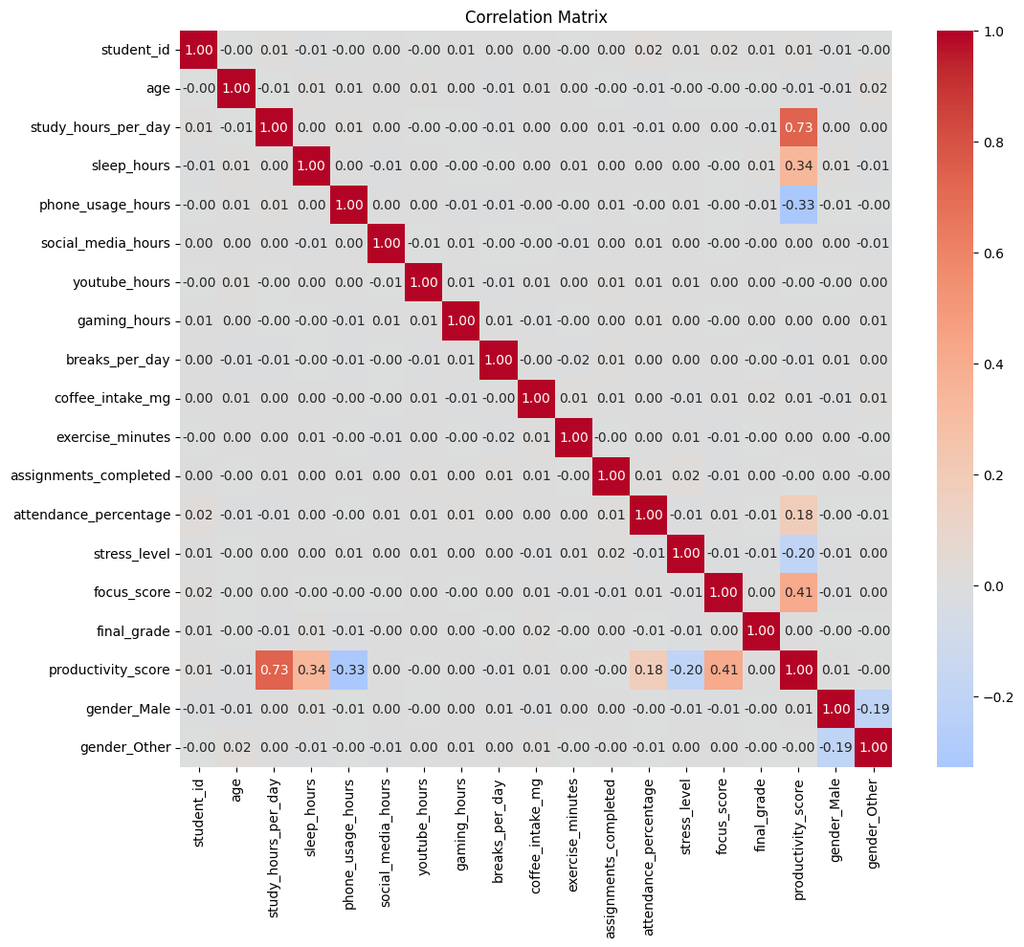

```python
import pandas as pd
import seaborn as sns
import matplotlib.pyplot as plt

correlation_matrix = df_prod.corr(numeric_only=True)

# Of all variables, there seems to only be a correlation between study_hours_per_day, phone_usage_hours, sleep_hours, and producitivity score.
# study hours vs productivity
# phone usage hours vs productivity
# sleep hours vs productivity
plt.figure(figsize=(12, 10))
sns.heatmap(correlation_matrix, annot=True, cmap='coolwarm', center=0, fmt='.2f')
plt.title('Correlation Matrix')
plt.show()
```

Looking at the matrix it is clear that only a few of the variables have linear correlations. The 0.73 coefficent indicates that there appears to be a strong positive correlation between study hours per day and productivity score. Sleep hours (0.34), attendance percentage (0.18), and focus score (0.41) are also positively correlated with productivity score. Phone usage hours (-0.33) and stress level (-0.20) are both negatively correlated with productivity.

Next we want to futher understand the relationship between productivity score and a feature like phone usage hours. To get a better grasp on how productivity changes between groups with low, medium, and high phone usage we will use a box plot.

We split people into 3 groups. People with between (0-3] hours of phone usage are put in the group "low", people with between (3-6] hours of phone usage are put in the group "medium", and people with between (6-12] hours of phone usage are put in the group "high".

```
F-statistic: 959.6355340197306
p-value: 0.0

--Low Usage Group Statistics--
count    4340.000000
mean       57.529445
std        15.091408
min        11.310000
25%        46.460000
50%        57.850000
75%        68.542500
max       100.000000
Name: productivity_score, dtype: float64

--Medium Usage Group Statistics--
count    5243.000000
mean       52.562022
std        15.096511
min         9.210000
25%        41.605000
50%        52.450000
75%        63.285000
max        99.530000
Name: productivity_score, dtype: float64

--High Usage Group Statistics--
count    10417.000000
mean        45.919929
std         15.613573
min          0.000000
25%         34.410000
50%         46.040000
75%         57.270000
max         91.860000
Name: productivity_score, dtype: float64
```

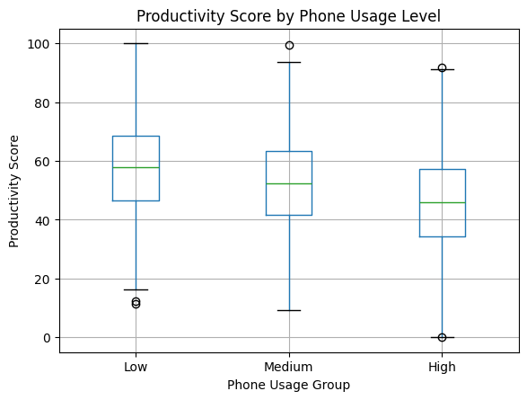

```python
from scipy.stats import f_oneway
import pandas as pd
import matplotlib.pyplot as plt

# Creating groups for comparison
df_prod['usage_group'] = pd.cut(
    df_prod['phone_usage_hours'],
    bins=[0, 3, 6, 12],
    labels=['Low', 'Medium', 'High']
)

low = df_prod[df_prod['usage_group'] == 'Low']['productivity_score']
medium = df_prod[df_prod['usage_group'] == 'Medium']['productivity_score']
high = df_prod[df_prod['usage_group'] == 'High']['productivity_score']

f_stat, p_value = f_oneway(low, medium, high)

print("F-statistic:", f_stat)
print("p-value:", p_value)

print("\n--Low Usage Group Statistics--")
print(low.describe())
print("\n--Medium Usage Group Statistics--")
print(medium.describe())
print("\n--High Usage Group Statistics--")
print(high.describe())

df_prod.boxplot(column='productivity_score', by='usage_group')

plt.title('Productivity Score by Phone Usage Level')
plt.suptitle('')
plt.xlabel('Phone Usage Group')
plt.ylabel('Productivity Score')

plt.show()
```

Looking at the plots you can see that the median productivity drops for the higher phone usage groups. The low group has a median of ~57, the medium group has a median of ~52, and the high group has a median score of ~46. It is also interesting that groups have large interquartile ranges and fairly big overlaps in productivity between groups. This means that having low phone usage doesn't necessarily gurantee you will be productive and a high phone usage doesn't gurantee you aren't productive.

In our Exploratory Data Analysis, we wanted to understand how digital behaviors affect measurable outcomes lke academic productivity and stress. While our ANOVA test proved that phone usage significantly impacts productivity, we also wanted to know the effects of digital usage on student stress levels.

The result of this exploration is one of the reasons why we decided to drop the other datasets in favor of the Student Productivity & Digital Distraction Dataset.

Commencing the analysis, we formulated the following hypothesis: Null Hypothesis: There is no difference in the mean stress levels of students who use wellness apps and those who do not. Alternative Hypothesis: There is a statistically significant difference in mean stress levels between the two groups.

We utilized an independent two-sample T-test with a standard significance level of a = 0.05

```
T-statistic: -0.2598
P-value: 7.9505e-01
```

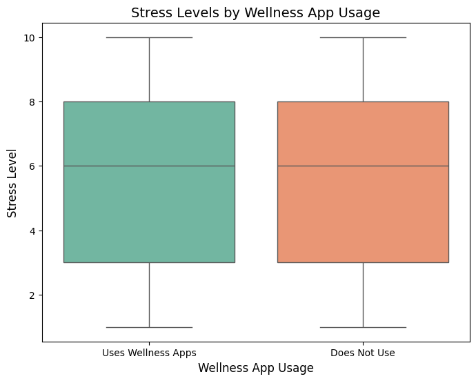

```python
from scipy.stats import ttest_ind

# 1. Prepare the data
# Filter the diet dataset into two groups based on wellness app usage
no_apps_stress = df_diet_clean[df_diet_clean['uses_wellness_apps'] == 0]['stress_level']
uses_apps_stress = df_diet_clean[df_diet_clean['uses_wellness_apps'] == 1]['stress_level']

# 2. Do a standard Independent Two-Sample T-Test
t_stat, p_val = ttest_ind(no_apps_stress, uses_apps_stress, nan_policy='omit')

print(f"T-statistic: {t_stat:.4f}")
print(f"P-value: {p_val:.4e}")

# 3. Creating box-plot
plt.figure(figsize=(8, 6))

# Mapping 0 and 1 into strings
plot_data = df_diet_clean.copy()
plot_data['Wellness_App_Status'] = plot_data['uses_wellness_apps'].map({0: 'Does Not Use', 1: 'Uses Wellness Apps'})

# Create the boxplot
sns.boxplot(
    x = 'Wellness_App_Status',
    y = 'stress_level',
    data = plot_data,
    hue='Wellness_App_Status',
    palette = 'Set2'
)

# Add titles and labels
plt.title('Stress Levels by Wellness App Usage', fontsize=14)
plt.xlabel('Wellness App Usage', fontsize=12)
plt.ylabel('Stress Level', fontsize=12)

# Show the plot
plt.show()
```

The results of our T-test yielded a p-value of 0.795. Because p > 0.05, we fail to reject the null hypothesis. This can be visually confirmed by our boxplot, which shows nearly identical medians, quartiles, and whiskers for both groups.

This result was a vital finding for our project, because since we failed to show any significance, and because our initial datasets could not be cleanly merged, we made the decision to retire this dataset and focus our Primary analysis and Machine Learning architecture on the student_productivity dataset. Our previous analysis through correlation matrices and ANOVA showed that sleep, study hours, and geneeral screen time are much more relevant to our analysis than this.

# Primary analysis

```python
import pandas as pd
import numpy as np
import matplotlib.pyplot as plt
import seaborn as sns
from sklearn.model_selection import train_test_split
from sklearn.preprocessing import StandardScaler, OneHotEncoder
from sklearn.compose import ColumnTransformer
from sklearn.pipeline import make_pipeline
from sklearn.linear_model import LinearRegression
from sklearn.metrics import mean_squared_error, mean_absolute_error, r2_score
from sklearn.preprocessing import PolynomialFeatures

df_prod = df_prod.dropna(subset=['study_hours_per_day', 'phone_usage_hours', 'sleep_hours', 'productivity_score'])

X = df_prod[['study_hours_per_day', 'phone_usage_hours', 'sleep_hours']]
y = df_prod['productivity_score']

X_train, X_test, y_train, y_test = train_test_split(X, y, test_size=0.2, random_state=42)

print(X_train.shape)
print(X_test.shape)
print(y_train.shape)
print(y_test.shape)
```

```
(16000, 3)
(4000, 3)
(16000,)
(4000,)
```

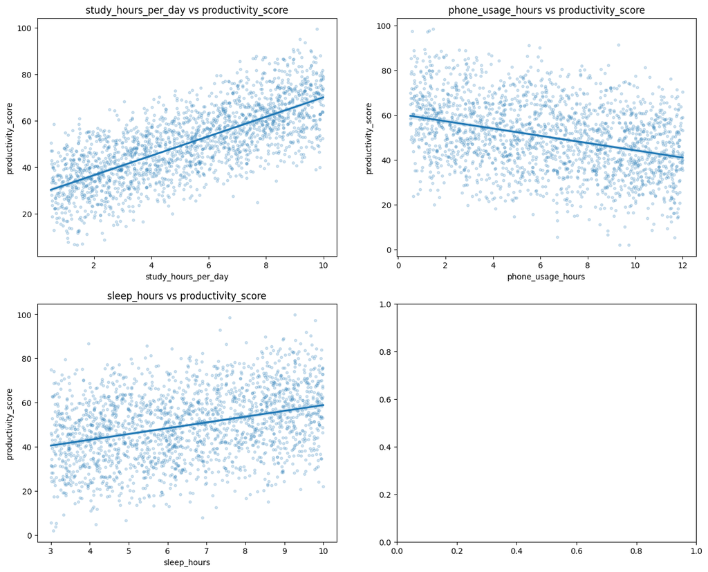

```python
import seaborn as sns
import matplotlib.pyplot as plt

# Features to visualize
features_to_plot = ['study_hours_per_day', 'phone_usage_hours', 'sleep_hours']
target = 'productivity_score'

fig, axes = plt.subplots(2, 2, figsize=(15, 12))
axes = axes.flatten()

for i, col in enumerate(features_to_plot):
    # Sample 2,000 points
    sns.regplot(data=df_prod.sample(2000), x=col, y=target,
                ax=axes[i],
                scatter_kws={'alpha':0.2, 's':10})
    axes[i].set_title(f'{col} vs {target}')


plt.show()
```

The scatter plots confirm the correlations identified in the heatmap. Study hours per day shows a clear positive trend with productivity score, meaning students who study more tend to score higher. Phone usage hours shows a negative trend, where more time on the phone is associated with lower productivity. Sleep hours also shows a modest positive relationship. These visuals give us confidence that these three features are worth using as inputs for our predictive models.

```python
from sklearn.linear_model import LinearRegression

# Evaluation
def evaluate_model(Y_train, Y_train_pred, Y_test, Y_test_pred):
    mse_train = mean_squared_error(Y_train, Y_train_pred)
    mse_test = mean_squared_error(Y_test, Y_test_pred)

    r2_train = r2_score(Y_train, Y_train_pred)
    r2_test = r2_score(Y_test, Y_test_pred)

    return mse_train, mse_test, r2_train, r2_test

model = make_pipeline(StandardScaler(), LinearRegression())
model.fit(X_train, y_train)

y_train_pred = model.predict(X_train)
y_test_pred = model.predict(X_test)
y_pred = y_test_pred
mse_train, mse_test, r2_train, r2_test = evaluate_model(y_train, y_train_pred, y_test, y_test_pred)

print(f"MSE Train Score: {mse_train:.4f}")
print(f"MSE Test Score: {mse_test:.4f}")
print(f"R-squared Train Score: {r2_test:.4f}")
print(f"R-squared Test Score: {r2_train:.4f}")
```

```
MSE Train Score: 61.0512
MSE Test Score: 60.3025
R-squared Train Score: 0.7659
R-squared Test Score: 0.7643
```

The linear regression model achieved an R² of 0.77 and an MSE of 60.30 on the test set. This means that 77% of the variance in a student's productivity score can be explained entirely by just three variables: sleep amount, studying amount, and phone usage. Next, if we take the square root of the MSE, we get 7.76. This means that our model's predictions are on average only about 7.7 points off from the actual value. Finally, the fact that the Train MSE (61.05) and Test MSE (60.30) are so close, and the R-squared Train (0.766) and the R-squared Test (0.7643) are so close prove that this model has very little overfitting, show that this model can be generalized to other sets of data without losing performance. This proves that we're able to decently model productivity by using only three behavioral features, and the next step is to determine whether this can be improved upon by analyzing productivity with polynomial regression.

```python
def fit_model_poly(X_train, Y_train, degree):
    model = make_pipeline(PolynomialFeatures(degree), StandardScaler(), LinearRegression())
    model.fit(X_train, Y_train)
    return model

poly_model = fit_model_poly(X_train, y_train, 3)
poly_model = fit_model_poly(X_train, y_train, 3)

y_train_pred = poly_model.predict(X_train)
y_test_pred = poly_model.predict(X_test)

mse_train, mse_test, r2_train, r2_test = evaluate_model(y_train, y_train_pred, y_test, y_test_pred)

print(f"MSE Train Score: {mse_train:.4f}")
print(f"MSE Test Score: {mse_test:.4f}")
print(f"R-squared Train Score: {r2_test:.4f}")
print(f"R-squared Test Score: {r2_train:.4f}")
```

```
MSE Train Score: 60.9769
MSE Test Score: 60.3092
R-squared Train Score: 0.7659
R-squared Test Score: 0.7646
```

The polynomial regression model with degree 3 produced results nearly identical to the linear regression baseline, with an R² of 0.76 and an MSE of 60.31 on the test set. This tells us that the relationship between these behavioral features and productivity does not have the kind of complex curves that polynomial terms are designed to capture. This means that with the question of picking one over the other, we would apply the principle of Occam's Razor, and pick Linear Regression since it achieves similar statistics while having a computational cost that's much less

```python
import torch
import torch.nn as nn
from sklearn.preprocessing import StandardScaler, MinMaxScaler
from sklearn.metrics import r2_score, mean_absolute_error

# Scale the input features so they are all on a similar scale
scaler = StandardScaler()
X_train_scaled = scaler.fit_transform(X_train)
X_test_scaled = scaler.transform(X_test)

# Scale the target variable to 0-1 range so the network trains more effectively
y_scaler = MinMaxScaler()
y_train_scaled = y_scaler.fit_transform(y_train.values.reshape(-1, 1))

# Convert everything to PyTorch tensors
X_tr_t = torch.tensor(X_train_scaled, dtype=torch.float32)
y_tr_t = torch.tensor(y_train_scaled, dtype=torch.float32)
X_te_t = torch.tensor(X_test_scaled, dtype=torch.float32)

# Define the network architecture
# Input layer: 3 features
# Hidden layer 1: 128 neurons with ReLU activation
# Dropout: randomly disables 20% of neurons during training to prevent overfitting
# Hidden layer 2: 64 neurons with ReLU activation
# Output layer: 1 neuron
class ProductivityNet(nn.Module):
    def __init__(self):
        super().__init__()
        self.net = nn.Sequential(
            nn.Linear(3, 128),
            nn.ReLU(),
            nn.Dropout(0.2),
            nn.Linear(128, 64),
            nn.ReLU(),
            nn.Dropout(0.2),
            nn.Linear(64, 32),
            nn.ReLU(),
            nn.Linear(32, 1)
        )
    def forward(self, x):
        return self.net(x)

# Create the model, optimizer, and loss function
model_nn = ProductivityNet()
optimizer = torch.optim.Adam(model_nn.parameters(), lr=0.001)
criterion = nn.MSELoss()

# Learning rate scheduler: cuts the learning rate in half every 50 epochs
# This helps the model fine-tune later in training
scheduler = torch.optim.lr_scheduler.StepLR(optimizer, step_size=50, gamma=0.5)

# Training loop: run through the data 200 times
for epoch in range(200):
    model_nn.train()
    optimizer.zero_grad()
    predictions = model_nn(X_tr_t)
    loss = criterion(predictions, y_tr_t)
    loss.backward()
    optimizer.step()
    scheduler.step()
    if (epoch + 1) % 40 == 0:
        print(f"Epoch {epoch+1}/200 | Loss: {loss.item():.4f}")

# Evaluate on test set
model_nn.eval()
with torch.no_grad():
    y_pred_scaled = model_nn(X_te_t).squeeze().numpy()

# Convert predictions back to original 0-100 range
y_pred_nn = y_scaler.inverse_transform(y_pred_scaled.reshape(-1, 1)).squeeze()

print(f"\nNeural Network R²:  {r2_score(y_test, y_pred_nn):.4f}")
print(f"Neural Network MAE: {mean_absolute_error(y_test, y_pred_nn):.4f}")
```

[output not shown]

The neural network required the most tuning of all three models. An initial run of 50 epochs produced a poor R² of 0.51, indicating the model had not learned the data well enough. After increasing training to 200 epochs, expanding the hidden layers, and adding a learning rate scheduler, the R² improved to over 0.7.

This is a classic illustration of Occam's Razor in data science: when a simpler model performs just as well as a more complex one, the simpler model is preferable. In addition, beyond simple computational efficiency, model interpretability is also important. It's not easy to look at a neural network and understood how the various weights and biases lead to that specific prediction. Conversely, linear regression is extremely easy to understand, with their being distinct coefficients attributed to each of the three variables, and this allows us to see how changing on variable will impact the student's final productivity score.

The fact that added complexity did not improve performance suggests that the relationship between students' behavioral habits and their productivity is fundamentally linear in nature. Given these results, the multivariate linear regression would be the most appropriate model for this dataset.

# Visualization

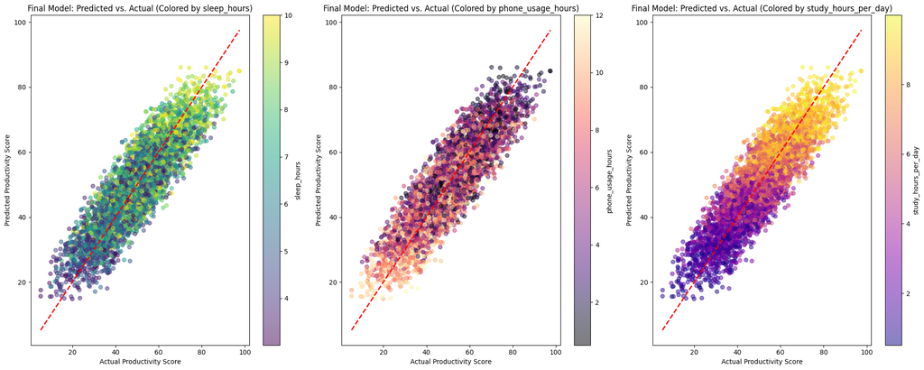

```python
# To compare different features
other_features = ['sleep_hours','phone_usage_hours', 'study_hours_per_day']
colormaps = ['viridis', 'magma', 'plasma']

fig, axes = plt.subplots(1, 3, figsize=(20, 8))

for i, feature in enumerate(other_features):
    # Scatter plots
    sc = axes[i].scatter(y_test, y_test_pred, c=X_test[feature], cmap=colormaps[i], alpha=0.5)

    axes[i].plot([y_test.min(), y_test.max()], [y_test.min(), y_test.max()], 'r--', lw=2)

    # Formatting
    axes[i].set_title(f'Final Model: Predicted vs. Actual (Colored by {feature})')
    axes[i].set_xlabel('Actual Productivity Score')
    axes[i].set_ylabel('Predicted Productivity Score')
    plt.colorbar(sc, ax=axes[i], label=feature)

plt.tight_layout()
plt.show()
```

To directly compare the performance of our two final models, we chose to make a bar chart and a predicted versus actual scatter plot side by side. The bar chart displays the R² and MAE scores for the linear regression and neural network, with exact values labeled on each bar for easy comparison at a glance. The scatter plot places each student from the test set as a point, with their actual productivity score on the x-axis and the model's predicted score on the y-axis, with both models overlaid in different colors. The two plots together provide both a numerical and visual summary of model performance.

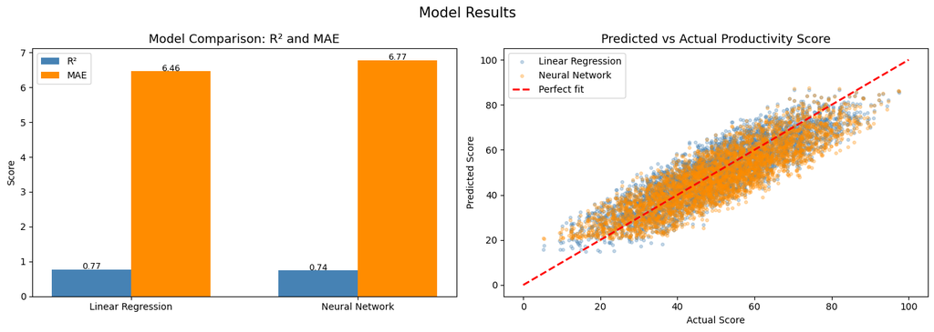

```python
# To compare the linear regression and nueral network
import matplotlib.pyplot as plt
import numpy as np

fig, axes = plt.subplots(1, 2, figsize=(14, 5))

# Plot 1: Bar chart comparing models
model_names = ['Linear Regression', 'Neural Network']
r2_scores = [r2_score(y_test, y_pred), r2_score(y_test, y_pred_nn)]
mae_scores = [mean_absolute_error(y_test, y_pred), mean_absolute_error(y_test, y_pred_nn)]

# Set up bar chart placement
x = np.arange(len(model_names))
width = 0.35
bars1 = axes[0].bar(x - width/2, r2_scores, width, label='R²', color='steelblue')
bars2 = axes[0].bar(x + width/2, mae_scores, width, label='MAE', color='darkorange')

axes[0].set_title('Model Comparison: R² and MAE', fontsize=13)
axes[0].set_xticks(x)
axes[0].set_xticklabels(model_names)
axes[0].set_ylabel('Score')
axes[0].legend()

for bar in bars1:
    axes[0].text(bar.get_x() + bar.get_width()/2, bar.get_height() + 0.01,
                 f'{bar.get_height():.2f}', ha='center', fontsize=9)
for bar in bars2:
    axes[0].text(bar.get_x() + bar.get_width()/2, bar.get_height() + 0.01,
                 f'{bar.get_height():.2f}', ha='center', fontsize=9)

# Plot 2: Predicted vs Actual scatter plot
# Each dot = one student in the test set
# X axis = their real productivity score
# Y axis = what the model predicted
axes[1].scatter(y_test, y_pred, alpha=0.3, s=10, color='steelblue', label='Linear Regression')
axes[1].scatter(y_test, y_pred_nn, alpha=0.3, s=10, color='darkorange', label='Neural Network')

# The red dashed line is what a perfect prediction would look like (predicted = actual)
axes[1].plot([0, 100], [0, 100], 'r--', linewidth=2, label='Perfect fit')

axes[1].set_title('Predicted vs Actual Productivity Score', fontsize=13)
axes[1].set_xlabel('Actual Score')
axes[1].set_ylabel('Predicted Score')
axes[1].legend()

plt.suptitle('Model Results', fontsize=15)
plt.tight_layout()
plt.show()
```

# Insights and Conclusions

This project investigated the relationship between students' digital habits and their academic productivity using that dataset. By applying statistical analysis and machine learning, we were able to identify meaningful patterns between phone usage, study hours, sleep, and productivity scores. Our first analysis used a one-way ANOVA test to determine whether phone usage level has a statistically significant effect on productivity. The results confirmed that it does. Students in the high usage group (6 to 12 hours per day) scored noticeably lower on productivity compared to those in the low usage group (0 to 3 hours per day), and this difference was statistically significant (p < 0.05). This means the result is unlikely to be due to random chance and reflects a real pattern in the data.

For the primary analysis, we trained and compared three predictive models. Linear regression served as our baseline and achieved an R² of 0.77 and a MAE of 6.46, meaning on average the model's predictions were off by about 6.5 points on a 0 to 100 scale. Polynomial regression with degree 3 did not improve on this, which is a meaningful finding in itself. It suggests the relationship between these behavioral features and productivity is fundamentally linear and does not have the kind of complex curves that polynomial terms are designed to capture.

Overall, the findings from this project suggest that student productivity is strongly and linearly tied to a small set of behavioral habits. Reducing phone usage, increasing dedicated study time, and maintaining consistent sleep are the most impactful levers a student can use to improve their academic output. Future work could explore a larger and more diverse real-world dataset, incorporate additional features such as mental health indicators or course difficulty, and experiment with more advanced architectures to see if non-linear models offer any advantage.